# Cyclistic_Case_Study

Mikael Tameru

2025-07-18

# Cyclistic Bike-share Analysis

## Background

Cyclistic, a bike sharing company centralized in Chicago featuring over 5800 bicycles and 600 docking stations, has decided to maximize their customer subscription rate to ensure their future success. With a large variety of options for people with disabilities and riders who can’t use traditional bikes, they have garnered a large number of leisurely riders while ensuring they have a stable base of users biking to their work and back.

Lily Moreno, the director of marketing at Cyclistic, determined that the best way to ensure its future success is to increase their number of annual memberships. As such, this analysis will look into the usage of bikes and see how they differ between existing subscribers and casual riders, deciding whether or not a new marketing strategy to increase membership rates by targeting casual riders will lead to future success.

## Ask

Throughout this case study, the question being answered is as follows: “How do annual members and casual riders use Cyclistic bikes differently?”

This question prompts us to look at the riding habits of annual members and casual riders and see what is different between them. We will see what is the best path to expanding the amount of subscribers by seeing what is popular among the users, who will be more inclined to become a subscriber, and how to best market the subscription service to get maximum retention among the most likely candidates.

## Prepare

In preparing for analysis two data sets were given from Cyclistic’s public data and were used for the analysis. Both data sets have values for each instance a bike was used, with a duration, a starting station, and an end station, as well as whether the person using the bike is a subscriber or a casual user. The 2019 dataset also has information on the gender and birth year of the users, while the 2020 dataset has information on the longitude and latitude of the starting and ending stations.

From all of this information, we will use the station names, the ride durations, and the age/gender from the 2019 dataset to conduct analysis on. The rest of the data will not be used in this analysis since it doesn’t relate to the objective of this data analysis, and will not provide any beneficial insight to the stakeholders regarding boosting subscription rates.

## Process

For this analysis, the two datasets were processed using Google Sheets and its data-cleaning functionality. The first step was to use the trim whitespace and remove duplicates functions on the entire dataset to check for those in the data. After this was done, the data was then filtered and searched to locate any empty values which were then removed from the data, which removed 18,022 rows between both datasets. Once this was done, columns that had numeric values were ensured to have correct types, and any misspelled values were checked using pivot tables.

The 2020 data was lacking over half of the trip duration data, which was easily calculated and inserted into all values. Other than that, no other data had to be modified in order to ensure the veracity of the data.

The integrity of the data was maintained during this cleaning process as all of this was done to a copy of the data, while Cyclistic’s original dataset remained unmodified. On top of this, every step in the cleaning process was logged and kept track of. As such, the data is ready to analyze.

## Analysis and Share

In order to perform the analysis on the cleaned datasets, they needed to be modified first to show the ride length and day of the week for each ride. As such, here is how they were loaded and mutated:

```r
# Load 2019 Data
df_2019 <- read_csv("Divvy_Trips_2019_Q1.csv") %>%
  clean_names() %>%
  mutate(
    start_time = mdy_hms(start_time),
    end_time = mdy_hms(end_time),
    ride_length = as.numeric(difftime(end_time, start_time, units = "mins")),
    day_of_week = wday(start_time, label = TRUE),
    member_casual = if_else(usertype == "Subscriber", "member", "casual"),
    age = 2019 - birthyear
  ) %>%
  rename(started_at = start_time, ended_at = end_time) %>%
  filter(ride_length > 0, !is.na(gender), !is.na(birthyear), birthyear > 1920 & birthyear < 2010)
# Load 2020 Data
df_2020 <- read_csv("Divvy_Trips_2020_Q1.csv") %>%
  clean_names() %>%
  mutate(
    started_at = ymd_hms(started_at),
    ended_at = ymd_hms(ended_at),
    ride_length = as.numeric(difftime(ended_at, started_at, units = "mins")),
    day_of_week = wday(started_at, label = TRUE)
  ) %>%
  filter(ride_length > 0)
```

Once the datasets were given the extra columns, they needed to be combined as shown here:

```r
all_trips <- bind_rows(
  df_2020 %>% dplyr::select(started_at, ended_at, ride_length, day_of_week, member_casual),
  df_2019 %>% dplyr::select(started_at, ended_at, ride_length, day_of_week, member_casual)
)
```

Once the data was combined and consolidated into the “all_trips” table, it became ready to analyze on how the differences between the casual riders and the subscribers came into play.

### Ride Length Overview

Showcased here is how the ride lengths were analyzed in order to see the average, median, and standard deviation for all rides, grouping all casual or subscribing riders together to highlight their totals.

| member_casual | avg_duration | median_duration | sd_duration | total_rides |
| --- | --- | --- | --- | --- |
| casual | 89.72139 | 21.10 | 1627.5590 | 54204 |
| member | 13.23557 | 8.45 | 273.7252 | 717721 |

From this, one can see how the average duration of trips hovers at around 90 minutes for casual members, while subscribers’ average is much lower at 13 minutes. Given that the standard deviation for casual riders is exceptionally large at over 1600 minutes, the data spreads greatly, which means the average could be skewed, which is consistent with the median being 21 minutes. Because of this, there are a large section of casual users who bike for shorter times with a smaller portion biking for an extended duration.

While this is the case for casual users, subscribers have a lot more consistent usage, as shown with the lower standard deviation on the much larger section of data. Since this is the case, and the average is significantly lower for subscribers, there could be an advertisement campaign to target any casual users who are using bikes for a shorter duration since they match the habits of subscribers.

### Rides by Weekday (With Counts)

In order to see the changes from one day to another, two columns were created, showcasing the percent of all rides in data (split between casual riders and subscribers) for a particular weekday. As shown below, this division was shown in the column chart, showcasing how the number of rides change based on the day of the week.

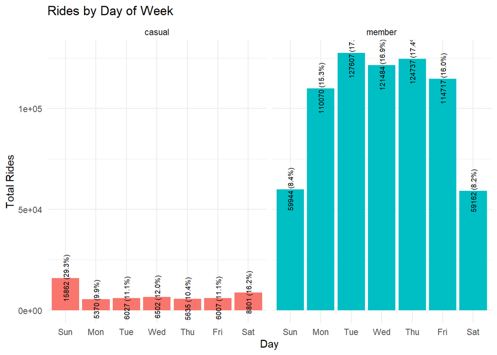

Based on this chart, one can deduce that members use the bike share mostly on weekdays, while almost half of all casual users ride bikes during the weekends. Looking at this one can infer that using some form of advertising during the weekends for showcasing the benefits of membership to casual users would be the most effective in garnering new members.

### Station Popularity Analysis

Cyclistic operates numerous bike-sharing stations throughout Chicago. Understanding which stations are most frequently used allows the marketing team to identify high-traffic areas for targeted campaigns. Below are insights into the most popular start and end stations, as well as the most common trip connections.

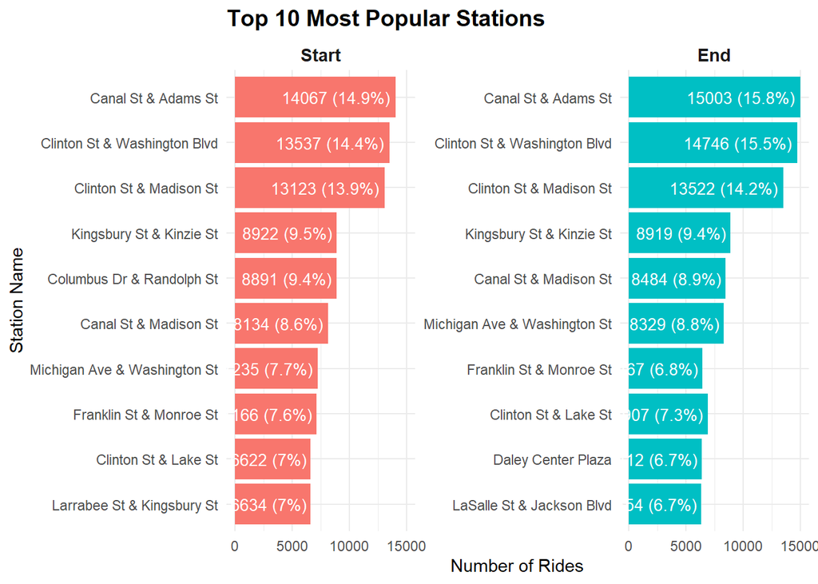

The top 10 most popular starting and ending Stations represent the most frequent origins and likely to finish for rides, suggesting high foot traffic or strategic locations like downtown hubs or transit intersections.

The graphs show that the top four stations for both starting and ending stations are the same, revealing where riders are likely to start and finish trips—often are near business districts, residential areas, or recreation zones.

#### Top 10 Most Common Station Pairs (Connections)

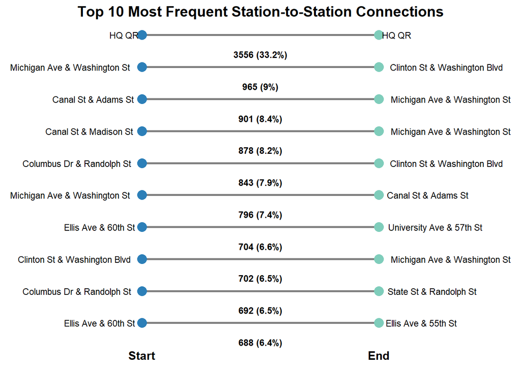

The top connections reflect popular commuting or leisure routes, which could benefit from promotional partnerships or added infrastructure. Starting stations and ending stations often overlap but are not always the same, suggesting asymmetry in travel patterns.

Marketing efforts should focus on the top 3–5 stations for physical promotions, and route-based advertisements might be most effective between frequently connected stations.Special attention should be given to  
Columbus Dr & Randolph St station.

### Rider Duration Distribution with a Normal Overlay

In order to showcase the distribution of ride lengths and show how they differ based on whether they are casual riders or subscribers, the data was summarized into the mean and standard deviations of each type and then plotted to show their normal distribution chart. Ride lengths more than 60 minutes were excluded in this section since there were a number of rides lasting multiple weeks, which would make the chart impossible to scale effectively.

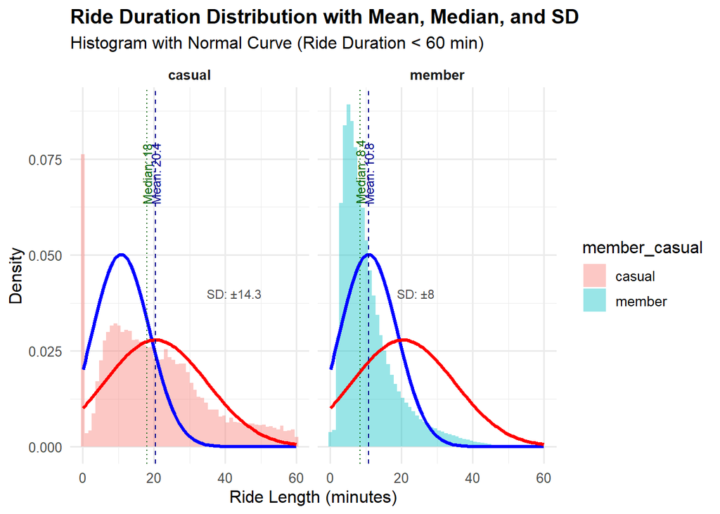

From the graph we see that the mean, median and standard deviations for the members are very low compared to the casual. From this normal distribution showcased of each user type shown we can see that the casual is highly variable as we can see from the standard deviation 14.3 compared to 8 for the members.

### Ride Duration by Gender and User Type (2019 only)

The 2019 data set also included gender and age, which allows us to look into those factors to further expand on demographics to be targeted for advertising. In this case, we looked at the differences of ride durations based on gender as shown in the following table:

| member_casual | gender | avg_duration | sd_duration | median_age | total_rides |
| --- | --- | --- | --- | --- | --- |
| casual | Female | 38.15748 | 81.49732 | 27 | 1875 |
| casual | Male | 36.49548 | 195.65755 | 28 | 4059 |
| member | Female | 14.65700 | 166.21607 | 33 | 65043 |
| member | Male | 13.66897 | 342.02085 | 35 | 274271 |

As seen with this table, there isn’t a lot of variation between genders other than the number of rides, as there are many more male users than female users. However, there is a big difference between casual and member rides shown in their use times and ages. This difference showcases that casual members go on longer rides, and they tend to be younger in comparison to subscribers. And so in order to effectively advertise to casual riders the marketing team should focus on younger users using bikes for longer, with no gender targeting.

To compare the ride lengths between members and casual users, we need to look at the member usage to see if there really is a big difference between members using bikes on weekends vs weekdays.

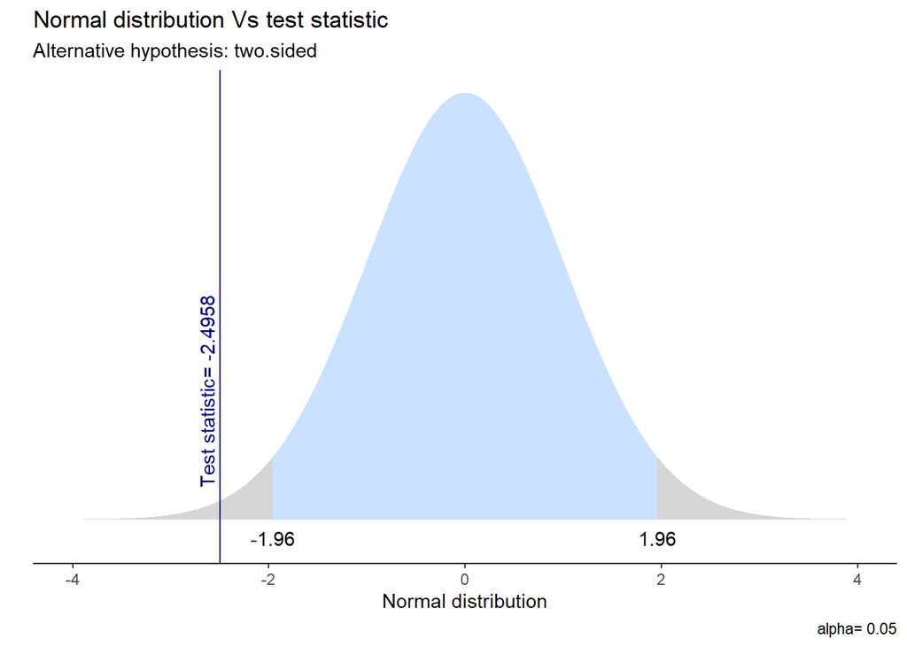

## Act

As seen with the results of the analysis, the best way to market Cyclistic’s subscription service would be to target the weekend casual riders, specifically using the most popular stations, and advertise the convenience behind a subscription. This could be done with several styles of posters, either on the bikes, in the stations or even along the route between stations. Another way to increase subscription rates would be to advertise to casual users of the bikeshare app such as through advertisements after securing a ride.

To expand my finding, some easy data would be finding out more seasonal-based habits and trends, as since I only looked at the first three months of 2019 and 2020 I couldn’t objectively make conclusions on yearly trends from the data.

In conclusion, I recommend * targeting younger casual users * targeting weekend casual riders * targeting high traffic stations and routes

Following these three recommendations, Cyclistic will expand its subscriber base and maximize converting casual members to subscribers.